# Introduction to Data Science Final Project

Project Wine

Jonas, Eddie, Rishav, Anant

## Project Proposal

### Data Information

**Data: (5 points) Describe the data set you have chosen and where it comes from. If it has a license (such as a Creative Commons license), mention it. If it does not have a license, explain why you believe you are allowed to use these data for this project.**

1 - fixed acidity  
2 - volatile acidity  
3 - citric acid  
4 - residual sugar  
5 - chlorides  
6 - free sulfur dioxide  
7 - total sulfur dioxide  
8 - density  
9 - pH  
10 - sulphates  
11 - alcohol  
Output variable (based on sensory data):  
12 - quality (score between 0 and 10)

The dataset is from https://archive.ics.uci.edu/ml/datasets/wine+quality and is donated to the UCI Machine Learning Repository. It is available for use on this project by including the following citation:

P. Cortez, A. Cerdeira, F. Almeida, T. Matos and J. Reis. Modeling wine preferences by data mining from physicochemical properties. In Decision Support Systems, Elsevier, 47(4):547-553, 2009.

### Research Questions

**Research questions: (6 points) Come up with at least three research questions that you want to answer using these data. Make sure that at least two of these questions involve at least three variables. You are welcomed to create new variables based on existing ones. Note that you will have the option to update / revise / change these questions for your presentation at the end of the semester.**

**Research Question 1:**

*Can we predict with good accuracy the kind of wine (red or white) by looking at their chemical properties and concentrations of different substances in them, as given in the dataset?*

This might seem like a unimportant question to ask (since you can just look at the wine), but its an interesting experiment to run because those chemical compounds and properties refer to a certain taste profile, so the predictors that separate the two wines indicate the taste profile particular to them. There are over 11 different variables to consider.

Intended Approach:  
We can use logistic regression or decision trees to construct the prediction model. The outcome variable is a binary one, so we chose logistic regression or decision trees since they both methods for binary classification.

**Research Question 2:**

*Can we predict with good accuracy the quality of wine for both the red and the white varieties by considering their chemical properties and concentrations of different substances in them?*

Intended Approach:  
We want to make this a binary classification problem as well. We can split the possible values of the quality of wine (currently a numerical score between 0 and 10) into two bands representing two quality labels. For example, values between 0-6 could represent ‘bad’ wine, while values between 7-10 could represent ‘good’ wine. Once again, we have over 11 different variables to consider for our model.

We will then use logistic regression or a binary decision tree to construct our model.

**Research Question 3:**

*Can we identify the most significant predictors in terms of chemical compounds that make a good red wine or white wine? Are the predictors mostly the same for the two kinds of wine, or are they different?*

In this follow-up to the previous question, we intend to explore if the significant chemical parameters that make a good red wine are the same as those that make a good white wine. Are they mostly the same? Are they mostly different? How much do they influence the qualities of the two kinds of wine?

Intended Approach: This is contingent on what we end up using for our second research question. If we use the logistic regression, we might want to do a stepwise regression process and look at the significant p-values for the slopes in the systematic component of our model. If we use decision trees instead, we might want to create two trees – one for each kind of wine – and look at what parameters determine the branching of the trees at different levels.

### EDA

**EDA: (9 points) Perform exploratory data analysis (EDA) that addresses, but not necessarily fully answers, each of the three research questions you outlined above. Your EDA should contain numerical summaries and visualizations. Each R output or plot should be accompanied by a brief interpretation. Do not use more than 2 plots per research question.**

**General EDA**

```r
#Loading in Data and necessary libraries

redwine_data <- read.csv("winequality-red.csv")
whitewine_data <- read.csv2("winequality-white.csv")

whitewine_data[] <- lapply(whitewine_data, function(x) {
    if(is.factor(x)) {
      as.numeric(as.character(x))
      }
  else x
})
sapply(whitewine_data, class)
```

```
##        fixed.acidity     volatile.acidity          citric.acid
##            "numeric"            "numeric"            "numeric"
##       residual.sugar            chlorides  free.sulfur.dioxide
##            "numeric"            "numeric"            "numeric"
## total.sulfur.dioxide              density                   pH
##            "numeric"            "numeric"            "numeric"
##            sulphates              alcohol              quality
##            "numeric"            "numeric"            "integer"
```

```r
redwine_data$type <- "red"
whitewine_data$type <- "white"

wine_data <- rbind(redwine_data, whitewine_data)
```

To get a feel for the data, we look at the summaries for each dataset:

Red wine dataset:

```r
summary(redwine_data)
```

```
##  fixed.acidity   volatile.acidity  citric.acid    residual.sugar
##  Min.   : 4.60   Min.   :0.1200   Min.   :0.000   Min.   : 0.900
##  1st Qu.: 7.10   1st Qu.:0.3900   1st Qu.:0.090   1st Qu.: 1.900
##  Median : 7.90   Median :0.5200   Median :0.260   Median : 2.200
##  Mean   : 8.32   Mean   :0.5278   Mean   :0.271   Mean   : 2.539
##  3rd Qu.: 9.20   3rd Qu.:0.6400   3rd Qu.:0.420   3rd Qu.: 2.600
##  Max.   :15.90   Max.   :1.5800   Max.   :1.000   Max.   :15.500
##    chlorides       free.sulfur.dioxide total.sulfur.dioxide    density
##  Min.   :0.01200   Min.   : 1.00       Min.   :  6.00       Min.   :0.9901
##  1st Qu.:0.07000   1st Qu.: 7.00       1st Qu.: 22.00       1st Qu.:0.9956
##  Median :0.07900   Median :14.00       Median : 38.00       Median :0.9968
##  Mean   :0.08747   Mean   :15.87       Mean   : 46.47       Mean   :0.9967
##  3rd Qu.:0.09000   3rd Qu.:21.00       3rd Qu.: 62.00       3rd Qu.:0.9978
##  Max.   :0.61100   Max.   :72.00       Max.   :289.00       Max.   :1.0037
##        pH          sulphates         alcohol         quality
##  Min.   :2.740   Min.   :0.3300   Min.   : 8.40   Min.   :3.000
##  1st Qu.:3.210   1st Qu.:0.5500   1st Qu.: 9.50   1st Qu.:5.000
##  Median :3.310   Median :0.6200   Median :10.20   Median :6.000
##  Mean   :3.311   Mean   :0.6581   Mean   :10.42   Mean   :5.636
##  3rd Qu.:3.400   3rd Qu.:0.7300   3rd Qu.:11.10   3rd Qu.:6.000
##  Max.   :4.010   Max.   :2.0000   Max.   :14.90   Max.   :8.000
##      type
##  Length:1599
##  Class :character
##  Mode  :character
##
##
##
```

White wine dataset:

```r
summary(whitewine_data)
```

```
##  fixed.acidity    volatile.acidity  citric.acid     residual.sugar
##  Min.   : 3.800   Min.   :0.0800   Min.   :0.0000   Min.   : 0.600
##  1st Qu.: 6.300   1st Qu.:0.2100   1st Qu.:0.2700   1st Qu.: 1.700
##  Median : 6.800   Median :0.2600   Median :0.3200   Median : 5.200
##  Mean   : 6.855   Mean   :0.2782   Mean   :0.3342   Mean   : 6.391
##  3rd Qu.: 7.300   3rd Qu.:0.3200   3rd Qu.:0.3900   3rd Qu.: 9.900
##  Max.   :14.200   Max.   :1.1000   Max.   :1.6600   Max.   :65.800
##    chlorides       free.sulfur.dioxide total.sulfur.dioxide    density
##  Min.   :0.00900   Min.   :  2.00      Min.   :  9.0        Min.   :0.9871
##  1st Qu.:0.03600   1st Qu.: 23.00      1st Qu.:108.0        1st Qu.:0.9917
##  Median :0.04300   Median : 34.00      Median :134.0        Median :0.9937
##  Mean   :0.04577   Mean   : 35.31      Mean   :138.4        Mean   :0.9940
##  3rd Qu.:0.05000   3rd Qu.: 46.00      3rd Qu.:167.0        3rd Qu.:0.9961
##  Max.   :0.34600   Max.   :289.00      Max.   :440.0        Max.   :1.0390
##        pH          sulphates         alcohol         quality
##  Min.   :2.720   Min.   :0.2200   Min.   : 8.00   Min.   :3.000
##  1st Qu.:3.090   1st Qu.:0.4100   1st Qu.: 9.50   1st Qu.:5.000
##  Median :3.180   Median :0.4700   Median :10.40   Median :6.000
##  Mean   :3.188   Mean   :0.4898   Mean   :10.51   Mean   :5.878
##  3rd Qu.:3.280   3rd Qu.:0.5500   3rd Qu.:11.40   3rd Qu.:6.000
##  Max.   :3.820   Max.   :1.0800   Max.   :14.20   Max.   :9.000
##      type
##  Length:4898
##  Class :character
##  Mode  :character
##
##
##
```

Combined wine dataset:

```r
summary(wine_data)
```

```
##  fixed.acidity    volatile.acidity  citric.acid     residual.sugar
##  Min.   : 3.800   Min.   :0.0800   Min.   :0.0000   Min.   : 0.600
##  1st Qu.: 6.400   1st Qu.:0.2300   1st Qu.:0.2500   1st Qu.: 1.800
##  Median : 7.000   Median :0.2900   Median :0.3100   Median : 3.000
##  Mean   : 7.215   Mean   :0.3397   Mean   :0.3186   Mean   : 5.443
##  3rd Qu.: 7.700   3rd Qu.:0.4000   3rd Qu.:0.3900   3rd Qu.: 8.100
##  Max.   :15.900   Max.   :1.5800   Max.   :1.6600   Max.   :65.800
##    chlorides       free.sulfur.dioxide total.sulfur.dioxide    density
##  Min.   :0.00900   Min.   :  1.00      Min.   :  6.0        Min.   :0.9871
##  1st Qu.:0.03800   1st Qu.: 17.00      1st Qu.: 77.0        1st Qu.:0.9923
##  Median :0.04700   Median : 29.00      Median :118.0        Median :0.9949
##  Mean   :0.05603   Mean   : 30.53      Mean   :115.7        Mean   :0.9947
##  3rd Qu.:0.06500   3rd Qu.: 41.00      3rd Qu.:156.0        3rd Qu.:0.9970
##  Max.   :0.61100   Max.   :289.00      Max.   :440.0        Max.   :1.0390
##        pH          sulphates         alcohol         quality
##  Min.   :2.720   Min.   :0.2200   Min.   : 8.00   Min.   :3.000
##  1st Qu.:3.110   1st Qu.:0.4300   1st Qu.: 9.50   1st Qu.:5.000
##  Median :3.210   Median :0.5100   Median :10.30   Median :6.000
##  Mean   :3.219   Mean   :0.5313   Mean   :10.49   Mean   :5.818
##  3rd Qu.:3.320   3rd Qu.:0.6000   3rd Qu.:11.30   3rd Qu.:6.000
##  Max.   :4.010   Max.   :2.0000   Max.   :14.90   Max.   :9.000
##      type
##  Length:6497
##  Class :character
##  Mode  :character
##
##
##
```

**Research Question 1:**

Can we predict with good accuracy the kind of wine (red or white) by looking at the concentrations of various chemical compounds in them, as given in the dataset?

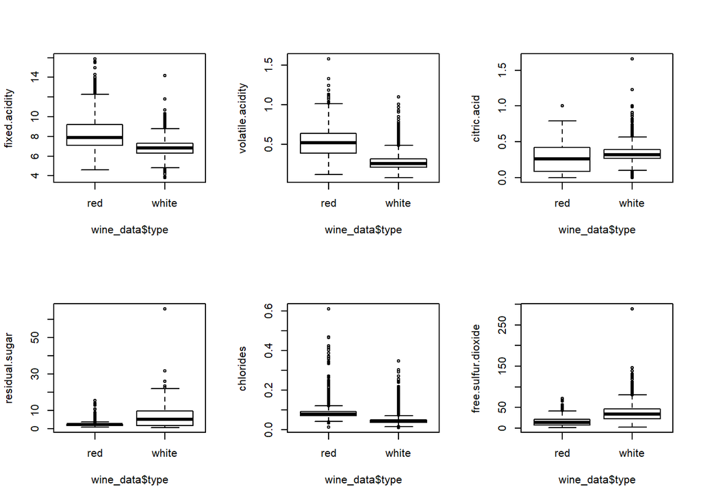

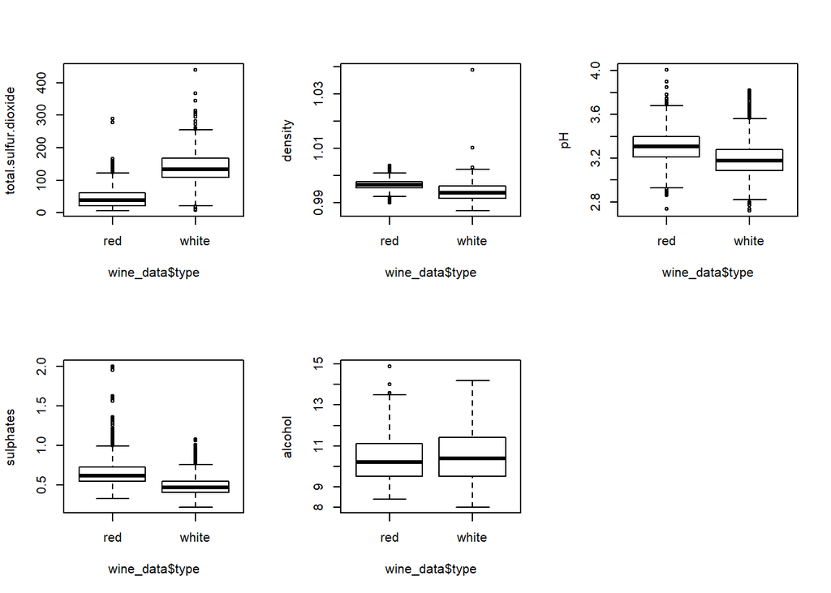

```r
#box-and-whiskers plot for each variable by type
par(mfrow=c(2,3))

for(i in 1:11){
  boxplot(wine_data[,i] ~wine_data$type, ylab = names(wine_data)[i])
}
```

Looking at the boxplots for each variable split by type, we can see that there are some concentrations of chemical compounds that we can use to separate red wines and white wines. For example, the fixed acidity, volatile acidity, residual sugar, chlorides, free sulfur dioxide, total sulfur dioxide, density and sulphates have inter-quartile ranges that are fairly different. Thus, they would probably be good predictors for the classification problem. We can tentatively put them as the predictors (8 of them) we are going to use, but we do not want to eliminate any of the 12 just yet before doing more analysis.

While individually they might be good predictors, using many input variables would help us build a model is a more accurate at predicting whether it is a red wine or white wine based on the chemical compounds. Thus, we consider a generalized linear model using logistic regression, and we also want to compare the results using a non-linear model like decision trees.

**Research Question 2:**

Can we predict with good accuracy the quality of wine for both the red and the white varieties by considering the concentrations of various chemical compounds in them?

```r
#Split into good and bad band (above 6 since 6 is the median)

redwine_data$qual_above_med <- (redwine_data$quality > 6)
whitewine_data$qual_above_med <- (whitewine_data$quality > 6)
wine_data$qual_above_med <- (wine_data$quality > 6)
```

1. Red wine:

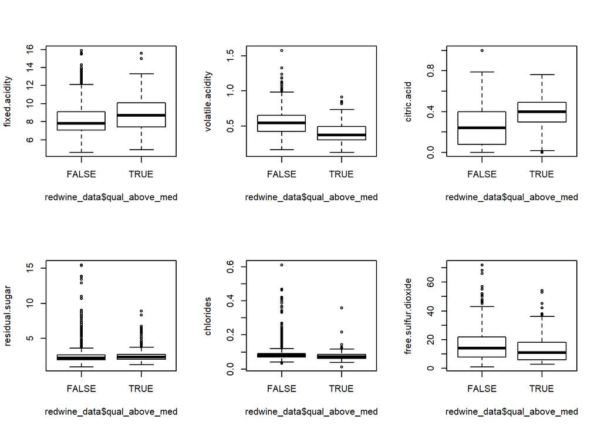

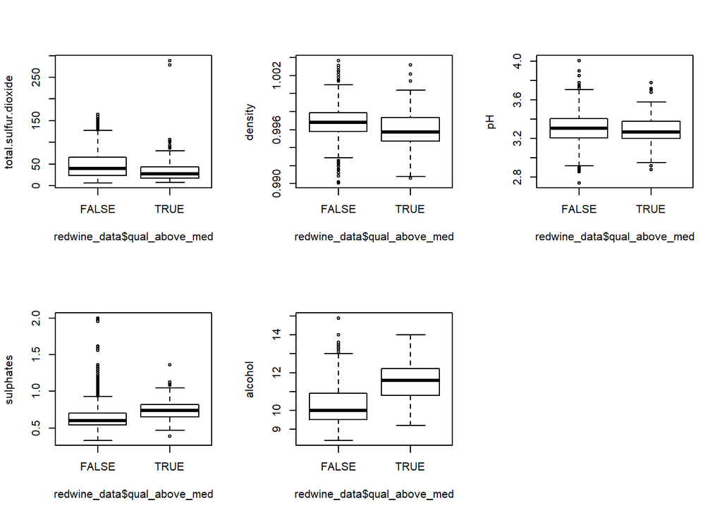

```r
#box-and-whiskers plot for each variable by type

par(mfrow=c(2,3))

for(i in 1:11){
  boxplot(redwine_data[,i] ~ redwine_data$qual_above_med, ylab = names(redwine_data)[i])
}
```

2. White wine:

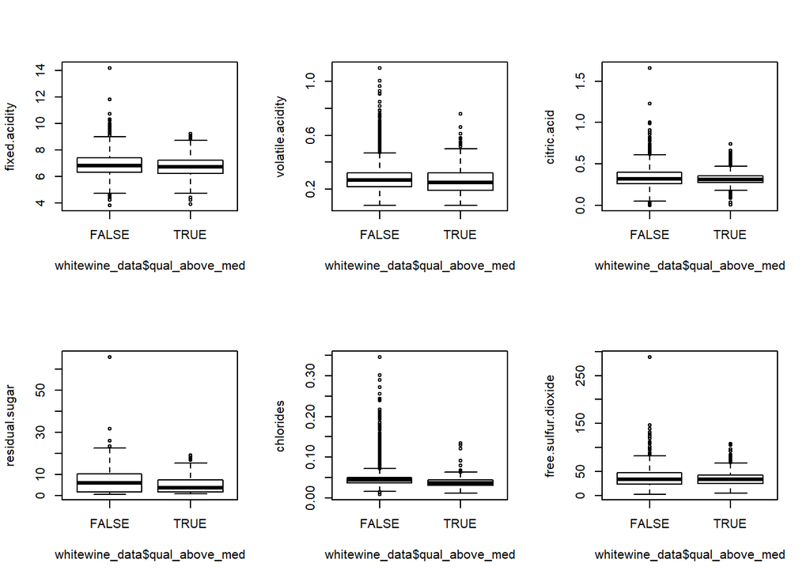

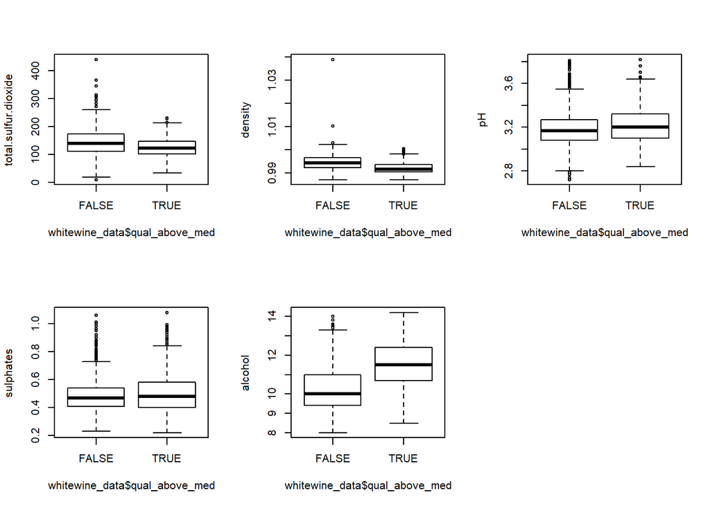

```r
#box-and-whiskers plot for each variable by type

par(mfrow=c(2,3))
for(i in 1:11){
  boxplot(whitewine_data[,i] ~ whitewine_data$qual_above_med, ylab = names(whitewine_data)[i])
}
```

Based on the boxplots for each variable split by type, we can see that the chlorides, total sulfur dioxide, the density and alcohol level all have inter-quartile ranges that are fairly different. Thus, these variables are probaby good predictors for classifying good white wines and bad white wines.

3. Red and White wine:

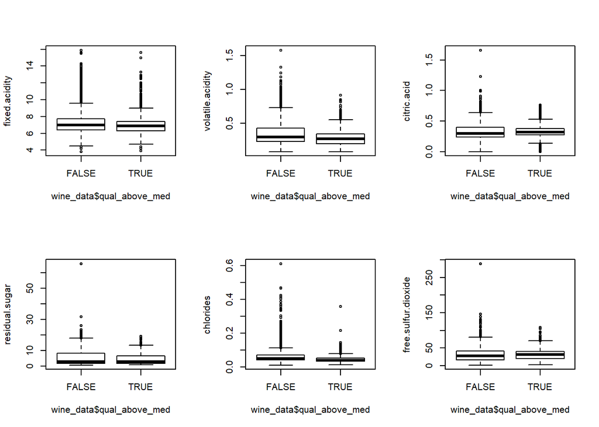

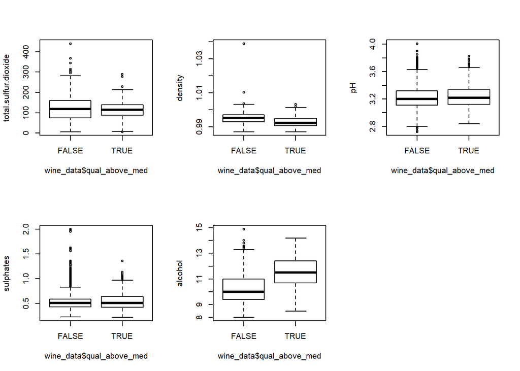

```r
#box-and-whiskers plot for each variable by type

par(mfrow=c(2,3))

for(i in 1:11){
  boxplot(wine_data[,i] ~wine_data$qual_above_med, ylab = names(wine_data)[i])
}
```

Based on the boxplots for each variable split by type, we can see that only the density and alcohol level have inter-quartile ranges that are fairly different. Thus, these two variables are probaby good predictors for classifying good wines and bad wines.

**Research Question 3:**

Can we identify the most significant predictors in terms of chemical compounds that make a good red wine or white wine? Are the predictors mostly the same for the two kinds of wine, or are they different?

The EDA for research question 3 is the same as research question 2, since it is a natural follow-up to research question 2.

### Timeline

**Timeline: (2 points) Sketch out a timeline for the work you will do each week to complete this project. Be realistic – discuss course schedules, travel plans, etc.**

Our project would proceed in the following 3 stages:

Stage 1: Proposal and Methodology

Week 10: 19 - 25 October

We will be working on the proposal, mainly on the EDA and thinking about the research questions for Wednesday’s submission, and we will continue refining the research questions and the methodology to answer each research question for the rest of the week. Ideally, we would try and combine the research questions together to form a more nuanced research question that combines a few techniques.

We assume that the feedback for the proposal will be back by Friday 23 October.

Week 11: 26 October - 1 November

For the start of Week 11, we will continue refining the research questions and decide on the methodology based on the feedback for the proposal. By Tuesday (27 October), we should have this finalized.

Stage 2: Data Analysis

Week 11: 26 October - 1 November

For the second half of Week 11, we will begin doing the data analysis for the research questions according to the methodology that we had set previously. By Friday (30 October), we will present initial results to each other for each of our subparts and decide on the next course of action.

Week 12: 2 - 8 November

We will continue doing data analysis based on the comments that we give each other during the initial results check-in the previous week. We would have another check-in on Tuesday or Wednesday (3-4 November) to present new findings. We will give comments to each other, but at this stage the analysis should be nearing completion.

If we do have any changes to make based on comments on Wednesday, we finalize the results by Friday. On Friday, we will have a small discussion on how best to visualize our results and who should take charge of which subsection of our project, which leads into our next stage.

Stage 3: Presentation

Week 13: 9 - 13 November

Based on the discussion we had on the presentation, we will work on our individual subparts until Tuesday on a shared slides document, updating each other along the way. On Tuesday and Wednesday, we will meet up to practice the presentation and to cohere our individual subparts together. Over the next few days, we will continuing doing so until we present on 13 November.

Deadline: 13 Nov

### Teamwork

**Teamwork: (3 points) Describe in detail how you will divide up the work between team members and what aspects of the project you will complete together as a team. Note that during the presentation session each member needs to be able to answer questions about all aspects of the work, regardless of whether they took the lead on that section or not.**

Again, we discuss this section in terms of the 3 stages we outlined in our timeline.

Stage 1: Proposal and Methodology

We will be doing the data set-up and cleaning, as well as the EDA for the proposal together. Following the submission of the proposal, we will be continuing to work as a team to refine the research questions and confirm on the methodology for the research question together as a team.

Ideally, we would have at least three subsections for the three research questions that we submit for our proposal. For the rest of this section, we assume we have three subsections, one for each research question.

Stage 2: Data Analysis

- Subsection 1: two people
- Subsection 2: one people
- Subsection 2: one people

We would be deciding this based on interest and which would take the most effort once we finalize the methodology. That means that each subsection has at least one person taking charge. Even so, we would have regular check-ins (Tuesdays/ Wednesdays and Fridays) to keep each other updated and to give each other comments. This ensures that each team member knows what is going on for the entire project.

Stage 3: Presentation

The initial stages for the preparation for the presentation would be done by the subsections decided above. These initial stages refer to expressing the results in terms of nice visuals.

Once we meet on Tuesday or Wednesday, we would be working together to combine the presentation into a coherent narrative.